# Clase 4: Inferencia Causal en R

Econometría 1 — ECON 3311 / ECON 3321

Brayan David Flórez | Profesor complementario

2026-19

> **Universidad de los Andes** | Facultad de Economía  
> Clase complementaria — Viernes 17 de julio · 7 a 10 AM  
> Profesor magistral: Edicson Luna · Complementario: Brayan David Flórez

# 1 Paquetes

```r
installed.packages("pacman")
```

[output not shown]

```r
library(pacman)
p_load(
  tidyverse,        # dplyr, ggplot2, tidyr
  broom,            # tidy(), glance(), augment()
  modelsummary,     # tablas de regresión
  patchwork,        # combinar gráficos
  scales,           # formato de ejes
  marginaleffects,  # efectos marginales promedio (APE)
  ivreg,            # variables instrumentales / 2SLS
  estimatr          # lm_robust() con errores estándar por clúster
)
```

# 2 De la correlación a la causalidad

> $\hat\beta$ de una regresión es un número. Que ese número tenga interpretación **causal** depende de un supuesto de identificación, no de qué tan bueno sea el ajuste ($R^2$) ni de qué tan significativo sea el coeficiente.

| Bloque | Pregunta que responde | Supuesto clave |
| --- | --- | --- |
| **A. Resultados potenciales** | ¿Cuál es el efecto de un tratamiento $D_i$ binario? | Asignación aleatoria / no hay sesgo de selección |
| **B. Variable binaria** | ¿Cómo interpreto una regresión cuando $Y_i \in \{0,1\}$? | Ninguno nuevo, es sobre *interpretación*, no identificación |
| **C. Variables instrumentales** | ¿Qué hago si $\text{Cov}(x_i,\epsilon_i)\neq 0$? | Relevancia + exclusión del instrumento |
| **D. Diferencias en diferencias** | ¿Cómo comparo un tratado y un control que empiezan distintos? | Tendencias paralelas |

Para sus trabajos: **primero identifiquen qué diseño tienen, y de ahí eligen la herramienta**.

# 3 BLOQUE A: Resultados potenciales y el problema fundamental

## 3.1 La idea

Para cada persona $i$ existen dos números que **nunca observamos los dos a la vez**:

$$y_i^1 \text{ (resultado si recibe el
tratamiento)}, \qquad y_i^0 \text{ (resultado si no lo
recibe)}$$

El efecto causal individual es $\tau_i = y_i^1 - y_i^0$. Lo que observamos es

$$y_i = y_i^1 D_i + y_i^0(1-D_i), \qquad
D_i = \begin{cases} 1 & \text{tratado} \\ 0 & \text{no
tratado}\end{cases}$$

**El problema fundamental de la inferencia causal:** solo vemos un estado de cada persona: el que corresponde a su $D_i$ real. El otro es un contrafactual que nunca ocurrió. Por eso $\tau_i$ no se puede calcular para *nadie* en la muestra: nos falta siempre una de las dos piezas. En una simulación, en cambio, nosotros *sí* podemos generar ambas, por eso es la mejor forma de entender de dónde sale el sesgo de selección.

## 3.2 De dónde sale la fórmula: la descomposición algebraica

Este es el resultado que conecta resultados potenciales con lo que efectivamente podemos calcular en datos. Partiendo de $y_i = y_i^1 D_i + y_i^0(1-D_i)$, tomamos esperanza condicional en cada grupo:

$$\mathbb{E}[y_i\mid D_i=1] =
\mathbb{E}[y_i^1\mid D_i=1], \qquad \mathbb{E}[y_i\mid D_i=0] =
\mathbb{E}[y_i^0\mid D_i=0]$$

Entonces la diferencia de medias observada es

$$\mathbb{E}[y_i\mid D_i=1] -
\mathbb{E}[y_i\mid D_i=0] = \mathbb{E}[y_i^1\mid D_i=1] -
\mathbb{E}[y_i^0\mid D_i=0]$$

**El truco:** sumar y restar $\mathbb{E}[y_i^0\mid D_i=1]$ el resultado *sin* tratamiento de los mismos tratados. No lo observamos, pero es válido algebraicamente sumarlo y restarlo:

$$= \underbrace{\Big(\mathbb{E}[y_i^1\mid
D_i=1]-\mathbb{E}[y_i^0\mid D_i=1]\Big)}_{\tau_{ATT}} \;+\;
\underbrace{\Big(\mathbb{E}[y_i^0\mid D_i=1]-\mathbb{E}[y_i^0\mid
D_i=0]\Big)}_{\text{sesgo de selección}}$$

El primer paréntesis es exactamente $\tau_{ATT}$ (compara $y^1$ y $y^0$ **dentro** del mismo grupo de tratados). El segundo es qué tan distintos eran los dos grupos *incluso si nadie se hubiera tratado*: el sesgo de selección.

## 3.3 Simulación: estudiar y la nota del quiz

Generamos una “población” en la que conocemos los dos resultados potenciales de cada estudiante, y el efecto verdadero de estudiar.

```r
set.seed(123)
n <- 3000

# Habilidad no observada de cada estudiante
habilidad <- rnorm(n, mean = 0, sd = 1)

# Resultados potenciales
y0  <- 60 + 8 * habilidad + rnorm(n, 0, 5)   # nota si NO estudia
tau <- 10 + 2 * habilidad                     # efecto de estudiar (heterogéneo)
y1  <- y0 + tau                               # nota si SÍ estudia

ATE_verdadero <- mean(tau)
ATT_verdadero <- mean(tau[habilidad > median(habilidad)])  # solo referencia

cat("ATE verdadero (promedio de tau_i en toda la población):", round(ATE_verdadero, 2), "\n")
```

```
#> ATE verdadero (promedio de tau_i en toda la población): 10.03
```

Ahora simulamos **dos formas distintas** de decidir quién estudia:

```r
# (1) Datos observacionales: estudiar está correlacionado con la habilidad
#     (los estudiantes más hábiles autoseleccionan estudiar más)
prob_estudia <- pnorm(0.8 * habilidad)
D_obs  <- rbinom(n, 1, prob_estudia)
y_obs  <- ifelse(D_obs == 1, y1, y0)

# (2) Experimento aleatorizado (RCT): moneda al aire, sin relación con habilidad
D_rct  <- rbinom(n, 1, 0.5)
y_rct  <- ifelse(D_rct == 1, y1, y0)

diff_observacional <- mean(y_obs[D_obs == 1]) - mean(y_obs[D_obs == 0])
diff_rct           <- mean(y_rct[D_rct == 1]) - mean(y_rct[D_rct == 0])

cat("Diferencia de medias — datos observacionales:", round(diff_observacional, 2), "\n")
```

```
#> Diferencia de medias — datos observacionales: 19.16
```

```r
cat("Diferencia de medias — experimento aleatorizado:", round(diff_rct, 2), "\n")
```

```
#> Diferencia de medias — experimento aleatorizado: 9.52
```

```r
cat("ATE verdadero:                                  ", round(ATE_verdadero, 2), "\n")
```

```
#> ATE verdadero:                                   10.03
```

> **Nota:** la diferencia de medias es exactamente el $\hat\beta_1$ de `lm(y ~ D)`. Compruébenlo:

```r
tidy(lm(y_obs ~ D_obs))
```

| term | estimate | std.error | statistic | p.value |
| --- | --- | --- | --- | --- |
| (Intercept) | 55.99373 | 0.2404437 | 232.87669 | 0 |
| D_obs | 19.16165 | 0.3387987 | 56.55762 | 0 |

```r
tidy(lm(y_rct ~ D_rct))
```

| term | estimate | std.error | statistic | p.value |
| --- | --- | --- | --- | --- |
| (Intercept) | 60.331757 | 0.2677370 | 225.33964 | 0.000000e+00 |
| D_rct | 9.516025 | 0.3781334 | 25.16579 | 5.977241e-127 |

## 3.4 Por qué se rompe la comparación observacional

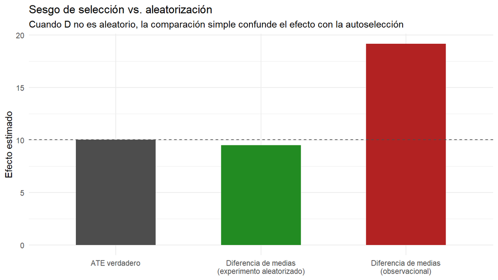

```r
comparacion <- data.frame(
  metodo = c("Diferencia de medias\n(observacional)",
             "Diferencia de medias\n(experimento aleatorizado)",
             "ATE verdadero"),
  valor  = c(diff_observacional, diff_rct, ATE_verdadero),
  tipo   = c("Sesgado", "Correcto", "Verdadero")
)

ggplot(comparacion, aes(x = metodo, y = valor, fill = tipo)) +
  geom_col(width = 0.55) +
  geom_hline(yintercept = ATE_verdadero, linetype = "dashed", color = "grey30") +
  scale_fill_manual(values = c("Sesgado" = "firebrick",
                                "Correcto" = "forestgreen",
                                "Verdadero" = "grey30")) +
  labs(
    title    = "Sesgo de selección vs. aleatorización",
    subtitle = "Cuando D no es aleatorio, la comparación simple confunde el efecto con la autoselección",
    x = NULL, y = "Efecto estimado", fill = NULL
  ) +
  theme_minimal() +
  theme(legend.position = "none")
```

## 3.5 ¿Positivo o negativo? La intuición de la dirección del sesgo

El sesgo de selección es $\mathbb{E}[y_i^0\mid D_i=1]-\mathbb{E}[y_i^0\mid D_i=0]$: compara el resultado **sin tratar** de los dos grupos. Su signo depende de *quién se autoselecciona*, no del efecto del tratamiento en sí:

- En nuestra simulación, los estudiantes más **hábiles** son los que más estudian (`prob_estudia` sube con `habilidad`), y la habilidad *también* sube la nota que sacarían sin estudiar ($y_i^0$). Como ambas cosas van en la misma dirección, $\mathbb{E}[y_i^0\mid D=1] > \mathbb{E}[y_i^0\mid D=0]$ → **sesgo positivo**: la comparación simple sobreestima el efecto de estudiar.
- Si en cambio quienes estudian fueran los estudiantes que **peor iban** (buscan compensar una base débil), tendríamos $\mathbb{E}[y_i^0\mid D=1] < \mathbb{E}[y_i^0\mid D=0]$ → sesgo **negativo**: la comparación simple subestimaría el efecto.

> **Para el examen:** pregúntense, el grupo que se autoselecciona al tratamiento, ¿ya venía mejor o peor *antes* de tratarse, en la característica no observada que les preocupa? Si venía mejor → sesgo positivo. Si venía peor → sesgo negativo. El signo del sesgo es sobre $y^0$, nunca sobre $\tau_i$.

## 3.6 SUTVA: el supuesto que se necesita incluso con aleatorización perfecta

La aleatorización garantiza $(y_i^1,y_i^0)\perp D_i$, es decir, sesgo de selección $=0$. Pero para que $y_i = y_i^1 D_i + y_i^0(1-D_i)$ tenga sentido en primer lugar, necesitamos además **SUTVA** (*Stable Unit Treatment Value Assumption*):

1. **No interferencia:** el resultado potencial de $i$ no depende de qué tratamiento reciban *los demás*, no hay efectos de contagio.
2. **Una sola versión del tratamiento:** “estar tratado” significa lo mismo para todos, no hay versiones ocultas distintas de $D_i=1$.

# 4 BLOQUE B: Variable dependiente binaria

## 4.1 La idea

Cuando $y_i \in \{0,1\}$ (empleado/no, default/no, formal/informal), su esperanza condicional se vuelve una **probabilidad**. La razón es puramente algebraica:

$$\mathbb{E}[y_i \mid x_i] =
1\cdot\mathbb{P}(y_i=1\mid x_i) + 0\cdot\mathbb{P}(y_i=0\mid x_i) =
\mathbb{P}(y_i=1\mid x_i)$$

Por eso llamamos a $p(x) := \mathbb{P}(y_i=1\mid x_i=x) = \mathbb{E}[y_i\mid x_i=x]$ la **probabilidad de respuesta**: es literalmente lo mismo que la regresión ya sabe estimar (una esperanza condicional), solo que ahora esa esperanza vive en $[0,1]$ y se interpreta como probabilidad. Todo el bloque es sobre qué forma funcional darle a $p(x)$.

Estudiamos tres formas de modelar $p(x)$:

| Modelo | Ecuación | $p(x) \in [0,1]$ garantizado |
| --- | --- | --- |
| **LPM** (`lm`) | $p(x_i) = \beta_0 + \beta_1 x_i$ | No |
| **Logit** (`glm`, link `logit`) | $p(x_i) = \Lambda(x_i'\beta)$ | Sí |
| **Probit** (`glm`, link `probit`) | $p(x_i) = \Phi(x_i'\beta)$ | Sí |

## 4.2 Simulación: educación y empleo

```r
set.seed(42)
n <- 2000

educ      <- round(runif(n, 0, 20))          # años de educación
habilidad2 <- rnorm(n)

# Modelo de variable latente: empleo* = b0 + b1*educ + habilidad + error logístico
y_latente <- -2 + 0.25 * educ + 0.5 * habilidad2 + rlogis(n)
empleo    <- as.integer(y_latente > 0)

df_bin <- data.frame(educ, empleo)

m_lpm    <- lm(empleo ~ educ,   data = df_bin)
m_logit  <- glm(empleo ~ educ,  data = df_bin, family = binomial(link = "logit"))
m_probit <- glm(empleo ~ educ,  data = df_bin, family = binomial(link = "probit"))
```

```r
modelsummary(
  list("LPM" = m_lpm, "Logit" = m_logit, "Probit" = m_probit),
  stars   = TRUE,
  gof_map = c("nobs"),
  coef_rename = c("(Intercept)" = "Intercepto", "educ" = "Educación (años)"),
  title = "Los coeficientes crudos NO son comparables entre modelos"
)
```

Los coeficientes crudos NO son comparables entre modelos

|  | LPM | Logit | Probit |
| --- | --- | --- | --- |
| Intercepto | 0.103*** | -2.027*** | -1.209*** |
|  | (0.018) | (0.113) | (0.064) |
| Educación (años) | 0.047*** | 0.248*** | 0.147*** |
|  | (0.002) | (0.011) | (0.006) |
| Num.Obs. | 2000 | 2000 | 2000 |

+ p < 0.1, * p < 0.05, ** p < 0.01, *** p < 0.001

**Problema 1 — predicciones fuera de** $[0,1]$. Nada obliga a $\beta_0+\beta_1 x_i$ a quedarse en $[0,1]$.

**La solución de Probit/Logit:** pasar el índice $x_i'\beta$ por una función $G$ creciente que aplasta toda la recta real dentro de $(0,1)$ — $\Phi$ (Normal) para Probit, $\Lambda$ (logística) para Logit. Como $G$ no es lineal, ya no existe una fórmula cerrada como la de OLS para minimizar errores al cuadrado; en su lugar, buscamos el $\hat\beta$ que hace **más probable haber observado los datos que efectivamente observamos**: máxima verosimilitud (`glm()` lo hace por ustedes).

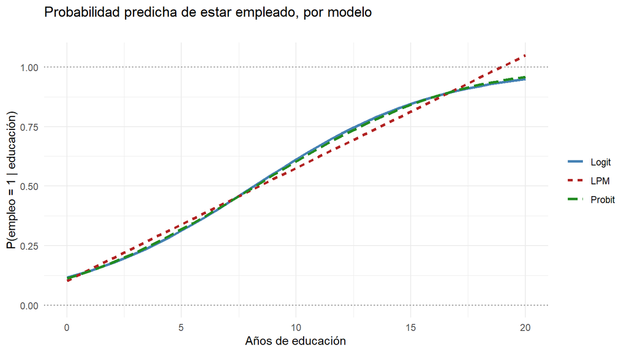

```r
grid <- data.frame(educ = seq(0, 20, by = 0.5))
grid$LPM    <- predict(m_lpm,    newdata = grid)
grid$Logit  <- predict(m_logit,  newdata = grid, type = "response")
grid$Probit <- predict(m_probit, newdata = grid, type = "response")

grid_largo <- grid |> pivot_longer(-educ, names_to = "modelo", values_to = "prob")

ggplot(grid_largo, aes(educ, prob, color = modelo, linetype = modelo)) +
  geom_line(linewidth = 1.1) +
  geom_hline(yintercept = c(0, 1), linetype = "dotted", color = "grey40") +
  scale_color_manual(values = c("LPM" = "firebrick", "Logit" = "steelblue", "Probit" = "forestgreen")) +
  labs(
    title    = "Probabilidad predicha de estar empleado, por modelo",
    subtitle = "",
    x = "Años de educación", y = "P(empleo = 1 | educación)",
    color = NULL, linetype = NULL
  ) +
  theme_minimal()
```

## 4.4 Reportando el efecto: PEA vs. APE

En Logit/Probit, $\hat\beta_j$ **no es** el efecto parcial. Por la regla de la cadena:

$$\frac{\partial\,\mathbb{P}(y_i=1\mid
x_i)}{\partial x_{ij}} = g(x_i'\hat\beta)\,\hat\beta_j, \qquad g =
G'$$

El signo de $\hat\beta_j$ sí les dice el signo del efecto (porque $g>0$ siempre), pero la magnitud depende de en qué $x_i$ evalúen $g$, por eso el número de la tabla de coeficientes no se puede leer “tal cual”. Usamos `marginaleffects::avg_slopes()` para obtener el **efecto parcial promedio (APE)**: el promedio, sobre todos los individuos de la muestra, de ese efecto parcial individual

```r
ape_lpm    <- avg_slopes(m_lpm,    variables = "educ")
ape_logit  <- avg_slopes(m_logit,  variables = "educ")
ape_probit <- avg_slopes(m_probit, variables = "educ")

bind_rows(
  data.frame(modelo = "LPM",    APE = ape_lpm$estimate,    se = ape_lpm$std.error),
  data.frame(modelo = "Logit",  APE = ape_logit$estimate,  se = ape_logit$std.error),
  data.frame(modelo = "Probit", APE = ape_probit$estimate, se = ape_probit$std.error)
) |>
  mutate(across(where(is.numeric), ~round(., 4)))
```

| modelo | APE | se |
| --- | --- | --- |
| LPM | 0.0473 | 0.0016 |
| Logit | 0.0413 | 0.0008 |
| Probit | 0.0419 | 0.0008 |

# 5 BLOQUE C: Variables instrumentales

## 5.1 La idea

Si $\text{Cov}(x_i, \epsilon_i) \neq 0$ (variable omitida, simultaneidad, error de medición), OLS es **inconsistente**. Un instrumento $z_i$ arregla esto si cumple:

- **Relevancia** (testeable): $\text{Cov}(z_i, x_i) \neq 0$
- **Exclusión** (NO testeable, se defiende con argumento económico): $\text{Cov}(z_i, \epsilon_i) = 0$

$$\hat\beta_1^{IV} =
\frac{\text{Cov}(z_i,y_i)}{\text{Cov}(z_i,x_i)}$$

## 5.2 Simulación: escolaridad, habilidad y salario

La habilidad afecta tanto la escolaridad como el salario, está “escondida” en el error de una regresión simple, generando endogeneidad.

```r
set.seed(7)
n <- 3000

habilidad3 <- rnorm(n)                    # no observada — vive en el error
z          <- rnorm(n)                    # instrumento: no está correlacionado con la habilidad

# La escolaridad depende del instrumento Y de la habilidad
escolaridad <- 12 + 1.5 * z + 2 * habilidad3 + rnorm(n, 0, 1)

# El salario depende de la escolaridad Y (otra vez) de la habilidad
BETA1_VERDADERO <- 0.8
salario <- 10 + BETA1_VERDADERO * escolaridad + 3 * habilidad3 + rnorm(n, 0, 2)

df_iv <- data.frame(salario, escolaridad, z)
```

```r
m_ols <- lm(salario ~ escolaridad, data = df_iv)
m_iv  <- ivreg(salario ~ escolaridad | z, data = df_iv)

modelsummary(
  list("OLS (sesgado)" = m_ols, "IV / 2SLS" = m_iv),
  stars   = TRUE,
  gof_map = c("nobs"),
  coef_rename = c("(Intercept)" = "Intercepto", "escolaridad" = "Escolaridad"),
  title = "Efecto de la escolaridad sobre el salario",
  notes = list(paste0("beta_1 verdadero (fijado en la simulación) = ", BETA1_VERDADERO))
)
```

Efecto de la escolaridad sobre el salario

|  | OLS (sesgado) | IV / 2SLS |
| --- | --- | --- |
| Intercepto | 0.324 | 9.970*** |
|  | (0.235) | (0.515) |
| Escolaridad | 1.607*** | 0.805*** |
|  | (0.019) | (0.042) |
| Num.Obs. | 3000 | 3000 |

+ p < 0.1, * p < 0.05, ** p < 0.01, *** p < 0.001  
beta_1 verdadero (fijado en la simulación) = 0.8

## 5.3 Chequeo obligatorio: la relevancia (primera etapa)

```r
m_primera_etapa <- lm(escolaridad ~ z, data = df_iv)
f_stat <- summary(m_primera_etapa)$fstatistic["value"]
cat("F-estadístico de la primera etapa:", round(f_stat, 1),
    ifelse(f_stat > 10, "→ instrumento fuerte (F > 10)", "→ ¡ALERTA! instrumento débil (F < 10)"), "\n")
```

```
#> F-estadístico de la primera etapa: 1407 → instrumento fuerte (F > 10)
```

## 5.4 El sesgo de OLS y la consistencia de IV, en repetidas muestras

```r
simular_iv <- function(n = 400) {
  a  <- rnorm(n)
  zz <- rnorm(n)
  ed <- 12 + 1.5 * zz + 2 * a + rnorm(n, 0, 1)
  wg <- 10 + BETA1_VERDADERO * ed + 3 * a + rnorm(n, 0, 2)
  d  <- data.frame(wg, ed, zz)
  c(
    ols = coef(lm(wg ~ ed, data = d))["ed"],
    iv  = coef(ivreg(wg ~ ed | zz, data = d))["ed"]
  )
}

resultados_iv <- t(replicate(1000, simular_iv()))
df_resultados <- as.data.frame(resultados_iv) |>
  pivot_longer(everything(), names_to = "metodo", values_to = "beta") |>
  mutate(metodo = case_when(
    str_starts(metodo, "ols") ~ "OLS",
    str_starts(metodo, "iv")  ~ "IV"
  ))
```

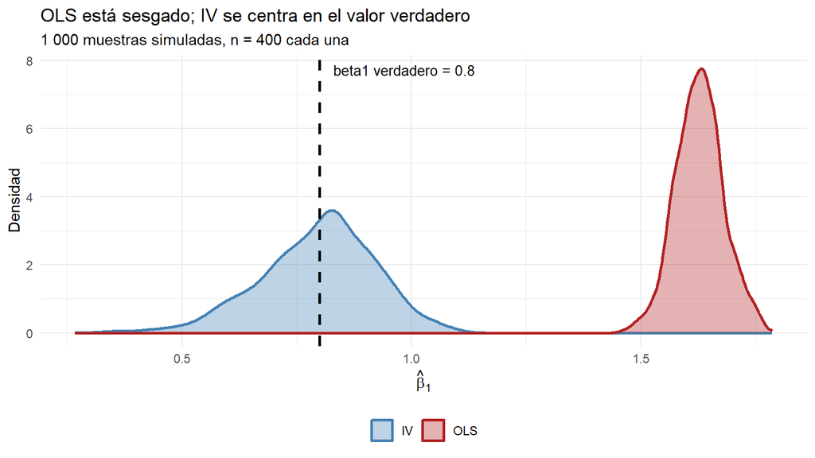

```r
ggplot(df_resultados, aes(x = beta, fill = metodo, color = metodo)) +
  geom_density(alpha = 0.35, linewidth = 0.9) +
  geom_vline(xintercept = BETA1_VERDADERO, linetype = "dashed", color = "black", linewidth = 1) +
  annotate("text", x = BETA1_VERDADERO + 0.03, y = Inf,
           label = paste0("beta1 verdadero = ", BETA1_VERDADERO),
           hjust = 0, vjust = 1.8, size = 3.5) +
  scale_fill_manual(values = c("OLS" = "firebrick", "IV" = "steelblue")) +
  scale_color_manual(values = c("OLS" = "firebrick", "IV" = "steelblue")) +
  labs(
    title    = "OLS está sesgado; IV se centra en el valor verdadero",
    subtitle = "1 000 muestras simuladas, n = 400 cada una",
    x = expression(hat(beta)[1]), y = "Densidad", fill = NULL, color = NULL
  ) +
  theme_minimal() +
  theme(legend.position = "bottom")
```

> **Para su trabajo:** si defienden un instrumento, esperen dos preguntas (1) ¿el $F$ de la primera etapa es alto? (lo pueden mostrar), y (2) ¿por qué el instrumento *solo* afecta a $Y$ a través de $X$? (lo tienen que argumentar, no lo pueden probar con una regresión).

## 5.5 Instrumento binario: el estimador de Wald

Cuando $z_i$ y $D_i$ son binarios (como en el sorteo militar de Vietnam que vieron en la magistral), el estimador de IV colapsa en una razón muy simple de calcular a mano.

$$\hat\beta_1^{Wald} =
\frac{\overbrace{\mathbb{E}[y\mid z=1]-\mathbb{E}[y\mid
z=0]}^{\text{forma reducida}}}{\underbrace{\mathbb{P}(D=1\mid
z=1)-\mathbb{P}(D=1\mid z=0)}_{\text{primera etapa}}}$$

```r
set.seed(55)
n <- 4000

elegible   <- rbinom(n, 1, 0.5)              # instrumento: elegibilidad al sorteo (aleatoria)
habilidad4 <- rnorm(n)                        # no observada

# La elegibilidad sube la probabilidad de ser veterano, pero no es la única causa
prob_veterano <- plogis(-0.5 + 1.2 * elegible + 0.3 * habilidad4)
veterano      <- rbinom(n, 1, prob_veterano)

# El salario depende de ser veterano Y de la habilidad (la fuente de endogeneidad)
salario_mil <- 20 - 2 * veterano + 4 * habilidad4 + rnorm(n, 0, 3)

df_wald <- data.frame(elegible, veterano, salario_mil)

forma_reducida <- mean(df_wald$salario_mil[df_wald$elegible == 1]) -
                   mean(df_wald$salario_mil[df_wald$elegible == 0])
primera_etapa  <- mean(df_wald$veterano[df_wald$elegible == 1]) -
                   mean(df_wald$veterano[df_wald$elegible == 0])
wald <- forma_reducida / primera_etapa

cat("Forma reducida   E[salario|z=1] - E[salario|z=0]:", round(forma_reducida, 3), "\n")
```

```
#> Forma reducida   E[salario|z=1] - E[salario|z=0]: -0.734
```

```r
cat("Primera etapa    P(vet|z=1) - P(vet|z=0):         ", round(primera_etapa, 3), "\n")
```

```
#> Primera etapa    P(vet|z=1) - P(vet|z=0):          0.274
```

```r
cat("Estimador de Wald (efecto del servicio militar):  ", round(wald, 3), "\n")
```

```
#> Estimador de Wald (efecto del servicio militar):   -2.683
```

```r
# El mismo número, calculado con ivreg() sobre el instrumento binario
tidy(ivreg(salario_mil ~ veterano | elegible, data = df_wald))
```

| term | estimate | std.error | statistic | p.value |
| --- | --- | --- | --- | --- |
| (Intercept) | 20.342298 | 0.3229587 | 62.987311 | 0.000000e+00 |
| veterano | -2.683248 | 0.5871645 | -4.569841 | 5.028271e-06 |

> Noten que `ivreg()` con un instrumento binario y un tratamiento binario reproduce **exactamente** la razón de Wald calculada a mano.

## 5.6 LATE: ¿el efecto para quién?

El instrumento no mueve el tratamiento de todo el mundo, solo el de algunos. Eso divide a la población en cuatro tipos, según cómo reaccionarían a cada valor del instrumento:

| Tipo | ¿Se trata si $z=0$? | ¿Se trata si $z=1$? | ¿El instrumento los mueve? |
| --- | --- | --- | --- |
| **Compliers** | No | Sí | Sí — es la gente cuyo tratamiento *depende* del instrumento |
| **Always-takers** | Sí | Sí | No — se tratan pase lo que pase |
| **Never-takers** | No | No | No — nunca se tratan |
| **Defiers** | Sí | No | Sí, pero al revés (los excluye el supuesto de monotonicidad) |

El estimador de Wald identifica el **LATE** (*Local Average Treatment Effect*): el efecto promedio del tratamiento, pero **solo para los compliers**. Es “local” porque *no* es el efecto para toda la población, de los always-takers y los never-takers no aprendemos nada, porque su tratamiento nunca cambia con $z$. Por eso, dos instrumentos distintos para la misma pregunta pueden dar efectos distintos: cada instrumento mueve a un grupo distinto de compliers, y el LATE que arroja es válido solo para ese grupo.

# 6 BLOQUE D: Diferencias en diferencias

## 6.1 La idea: dos comparaciones, cada una contaminada por su lado

Si un tratado y un control no son comparables desde el inicio, ninguna comparación simple sirve sola:

- **Antes vs. después, solo en el tratado.** Si algo más cambió con el tiempo, un choque macro, una tendencia general de la economía, lo confunden con el efecto del tratamiento. Es la **tendencia de tiempo** contaminando la comparación.
- **Tratado vs. control, solo después.** Si los dos grupos ya eran distintos desde el principio por características fijas propias de cada uno, confunden esa diferencia de nivel con el efecto. Es la **diferencia fija de grupo** contaminando la comparación.

DiD combina las dos comparaciones para que esas dos fuentes de contaminación se cancelen entre sí. Formalmente, escribimos el resultado *sin* tratamiento como

$$Y_{it}(0) = \alpha_i + \lambda_t +
u_{it}$$

- $\alpha_i$: nivel fijo de cada unidad/grupo (se cancela al diferenciar **en el tiempo**, dentro de cada grupo)
- $\lambda_t$: choque común de cada periodo (se cancela al diferenciar **entre grupos**, en cada punto del tiempo)

$$\hat\delta = \bigl(\bar
Y_{T,\text{post}} - \bar Y_{T,\text{pre}}\bigr) - \bigl(\bar
Y_{C,\text{post}} - \bar Y_{C,\text{pre}}\bigr)$$

## 6.2 El ejemplo clásico

```r
NJ_antes   <- 20.4; NJ_despues <- 21.0   # tratado: subió el salario mínimo
PA_antes   <- 23.3; PA_despues <- 21.2   # control: no subió

delta_NJ <- NJ_despues - NJ_antes
delta_PA <- PA_despues - PA_antes
DID_ck   <- delta_NJ - delta_PA

cat("Cambio en NJ (tratado):  ", round(delta_NJ, 2), "\n")
```

```
#> Cambio en NJ (tratado):   0.6
```

```r
cat("Cambio en PA (control):  ", round(delta_PA, 2), "\n")
```

```
#> Cambio en PA (control):   -2.1
```

```r
cat("Estimador DiD:            ", round(DID_ck, 2), " → el salario mínimo NO redujo el empleo\n")
```

```
#> Estimador DiD:             2.7  → el salario mínimo NO redujo el empleo
```

## 6.3 El problema de solo 2 periodos — y por qué queremos más años

Con un solo punto “antes” y un solo punto “después” (como en la tabla de Card-Krueger), la línea entre ellos es, por construcción, siempre recta, **no hay forma de ver si esa pendiente ya venía así desde antes**, o si es nueva. El supuesto de tendencias paralelas es sobre la *pendiente*, así que necesitamos varios periodos pre-tratamiento para poder verla. Simulamos un panel con **4 años antes** del tratamiento y **3 después**, en dos versiones: una donde el supuesto se cumple y otra donde no.

```r
set.seed(99)
n_unidades <- 200
periodos   <- -4:2                 # año 0 = primer año del tratamiento
EFECTO_VERDADERO <- 5
PENDIENTE_COMUN  <- 1.5            # crecimiento "natural" por año, común a ambos grupos

alpha_i <- rnorm(n_unidades, 0, 3)         # nivel fijo de cada unidad
grupo   <- rep(c("Tratado", "Control"), each = n_unidades / 2)

construir_panel_multi <- function(pendiente_extra_tratado) {
  map_dfr(periodos, function(t) {
    tratamiento_activo <- as.integer(grupo == "Tratado" & t >= 0)
    data.frame(
      id      = 1:n_unidades,
      grupo,
      periodo = t,
      y = 50 + alpha_i +
          PENDIENTE_COMUN * t +
          pendiente_extra_tratado * ifelse(grupo == "Tratado", t, 0) +  # pendiente propia del tratado (¡incluso antes de t=0!)
          EFECTO_VERDADERO * tratamiento_activo +
          rnorm(n_unidades, 0, 2)
    )
  }) |>
    mutate(tratado = as.integer(grupo == "Tratado"),
           post    = as.integer(periodo >= 0))
}

panel_paralelo <- construir_panel_multi(pendiente_extra_tratado = 0)    # mismo crecimiento pre-tratamiento
panel_violado  <- construir_panel_multi(pendiente_extra_tratado = 1.2) # el tratado YA crecía más rápido antes de tratarse
```

## 6.4 Viéndolo en el gráfico: ahora sí se nota la tendencia

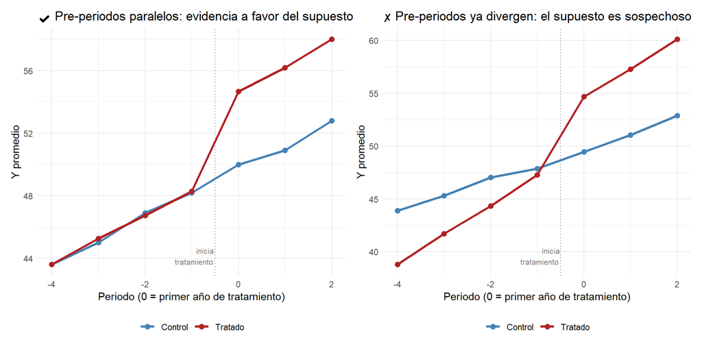

```r
graficar_multi <- function(panel, titulo) {
  medias <- panel |>
    group_by(grupo, periodo) |>
    summarise(media_y = mean(y), .groups = "drop")

  ggplot(medias, aes(periodo, media_y, color = grupo)) +
    geom_vline(xintercept = -0.5, linetype = "dotted", color = "grey50") +
    geom_line(linewidth = 1.1) +
    geom_point(size = 2.3) +
    annotate("text", x = -0.5, y = min(medias$media_y), label = "inicia\ntratamiento",
             hjust = 1.05, vjust = 0, size = 2.8, color = "grey50") +
    scale_color_manual(values = c("Tratado" = "firebrick", "Control" = "steelblue")) +
    labs(title = titulo, x = "Periodo (0 = primer año de tratamiento)", y = "Y promedio", color = NULL) +
    theme_minimal() +
    theme(legend.position = "bottom")
}

graficar_multi(panel_paralelo, "✔ Pre-periodos paralelos: evidencia a favor del supuesto") |
graficar_multi(panel_violado,  "✘ Pre-periodos ya divergen: el supuesto es sospechoso")
```

> **Esto es exactamente lo que se hace en la práctica (“chequeo de pre-tendencias”):** grafiquen las medias de tratado y control en **todos** los periodos previos al tratamiento. Si ya venían caminando paralelas antes de que ocurriera nada, es evidencia (no prueba) a favor del supuesto. Si ya divergían, el $\hat\delta$ que calculen después va a mezclar el efecto del tratamiento con una tendencia que ya existía.

*Clase preparada para Econometría 1 — ECON 3311 / ECON 3321 | Universidad de los Andes | 2026-19*